# LibraryDB

Berkay Zühre

October 1, 2020

## Library Database

In this project I have implemented a simple library database and user interface with SQLite Studio and Shiny package in R. Users can:

- Insert a book
- Delete a book
- Search book according to various fields
- Borrow books for 2 weeks

[Github Link](https://github.com/berkayzuhre/LibraryDB)

### Relation Definitions

I have created 4 tables to store the relevant data. Books, Authors, Users are real data. Borrowed Books Table is a combination of two real data tables. That is why it has two primary keys each one comes from a different real data table.

My tables are in conformity with the normal forms because there is no redundant, repeating data. For example, if I didn't have Authors table, I would have to store Author Name and age in every record of the books which would make it inefficient. In this format I only store the matching Author ID in each table, and I can reach the rest of the information by joining tables, if it becomes necessary.

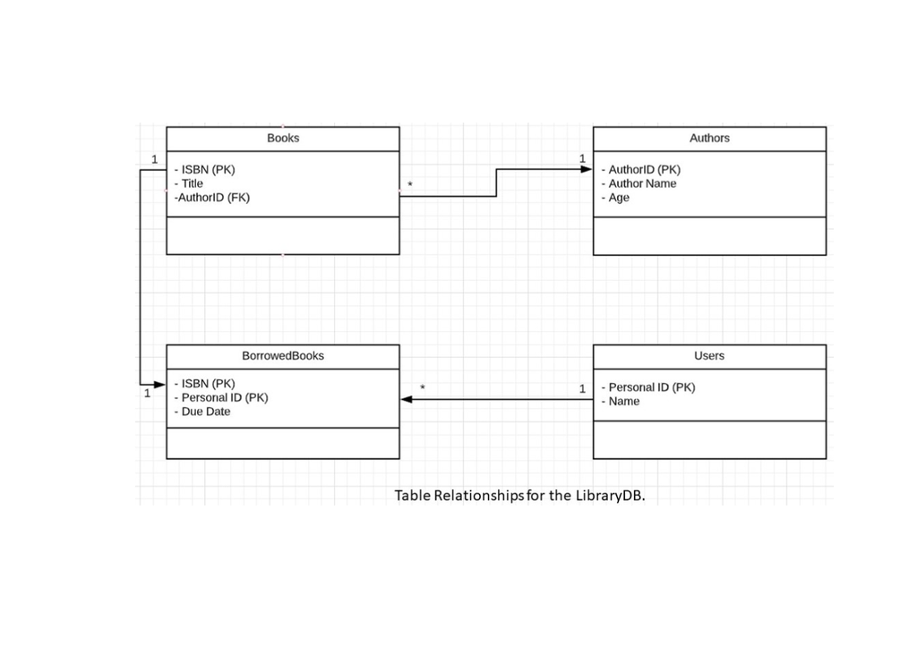

### Functions

Before running the app, I have defined several functions to access the database and make necessary modifications. Wjile the app is running we will simply reference these functions wh,ch will make it much less complicated.

#### Create Database

As mentioned above I have defined 4 different tables. This function will get called at the first run of the app since it only creates the necessary tables.

```r
library(shiny)
library(DBI)

defaultW <- getOption("warn")

options(warn = -1)

createDatabase<-function(con){
    dbSendQuery(conn=con,
                "CREATE TABLE Author (
  AuthorID   INTEGER PRIMARY KEY,
  AuthorName TEXT    NOT NULL,
  Age      INTEGER NOT NULL);
")

    dbSendQuery(conn=con,
                "CREATE TABLE User (
  PersonalID   INTEGER PRIMARY KEY,
  Name TEXT    NOT NULL);
")

    dbSendQuery(conn=con,
                "CREATE TABLE Book (
  ISBN   INTEGER PRIMARY KEY,
  Title TEXT    NOT NULL,
  AuthorID      INTEGER NOT NULL,
  FOREIGN KEY (AuthorID)
  REFERENCES Author (AuthorID));
")

    dbSendQuery(conn=con,
                "CREATE TABLE BorrowBook (
  ISBN   INTEGER,
  PersonalID INTEGER,
  DueDate DATETIME NOT NULL,
  PRIMARY KEY (ISBN, PersonalID)
  FOREIGN KEY (ISBN) REFERENCES Book (ISBN)
  FOREIGN KEY (PersonalID) REFERENCES User (PersonalID)
  );
")

}
```

#### Fill Database

This function will get called once as well. It simply fill up the tables with some dummy data so we can have a better start to using the app.

```r
fillDatabase<-function(con){

    writeTable(con,"User",c(1188,"Berkay Zuhre"))
    writeTable(con,"User",c(1000,"Ali Veli"))


    writeTable(con,"Author",c(1,"Aziz Nesin",43))
    writeTable(con,"Author",c(2,"Orhan Kemal",56))
    writeTable(con,"Author",c(3,"Yasar Kemal",90))
    writeTable(con,"Author",c(4,"Sabahattin Ali",40))
    writeTable(con,"Author",c(5,"Ayse Kulin",79))

}
```

#### Write Table

This is a general function for inserting data to tables. This is a general function for writing to tables mainly used for development.

```r
writeTable<-function(database,tableName,data){

    data=cbind.data.frame(t(data))

    fieldNames<-dbListFields(database, tableName)

    c<-strsplit(fieldNames," ")

    colnames(data)<-c

    dbWriteTable(conn=database, name=tableName, data, append=T, row.names=F)

}
```

#### Write Book - Delete Book

This is the main functionality of our app that users can insert and delete books from the database. I am aware that using "paste" for SQL queries is open to SQL injection threats but this app is not deployed in a server so it only works locally.

Write Book function takes Author Name but the Book table only has Author ID. So first I find the ID of the Author then insert to the Book Table.

```r
writeBook<-function(database,data){

    AuthorStr = paste("SELECT AuthorID FROM Author
                        WHERE Author.AuthorName='",data[3],"'",sep="")

    AuthorID = as.integer(dbGetQuery(conn=database,AuthorStr))

    data[3]=AuthorID

    data=cbind.data.frame(t(data))

    fieldNames<-dbListFields(database, "Book")

    c<-strsplit(fieldNames," ")

    colnames(data)<-c

    dbWriteTable(conn=database, name="Book", data, append=T, row.names=F)


}

deleteBook<-function(database,tableName,primaryKey){
    str=paste('DELETE FROM',tableName,'WHERE ISBN =',primaryKey)

    dbExecute(con,str)
}
```

#### Search Book - Borrow Book

Search Book query changes according to the field you want to make a search with because Author Name is stored in a different table. Borrow Book function first checks if the User has already borrowed 8 books or not. If they have borrowed 8 books the app gives an error.

```r
searchBook<-function(database,tableName,fieldName,filterValue){

    if(fieldName!="AuthorName"){

        str=paste("SELECT ISBN, Title, Author.AuthorName
FROM Book
    JOIN Author on Book.AuthorID = Author.AuthorID WHERE Book.",fieldName," = '",filterValue,"'",sep="")
        a<-data.frame(dbGetQuery(conn=con,str))
        return(a)}else{

            str=paste("SELECT ISBN, Title, Author.AuthorName
FROM Book
    JOIN Author on Book.AuthorID = Author.AuthorID
    WHERE
    Author.AuthorName = '",filterValue,"'",sep="")
            a<-data.frame(dbGetQuery(conn=con,str))
            return(a)
        }
}

borrowBook<-function(database,bookISBN,personalID){
    str2=paste("SELECT Count(BorrowBook.PersonalID)
          FROM BorrowBook
          Join User on User.PersonalID = BorrowBook.PersonalID
          Where BorrowBook.PersonalID = ",personalID," Group By BorrowBook.PersonalID;
          ")

    borrowedBookNum<-as.integer(data.frame(dbGetQuery(conn=con,str2)))

    if(is.na(borrowedBookNum)){
      writeTable(con,"BorrowBook",c(bookISBN,personalID,"2020-10-04"))
    }

    else if(borrowedBookNum==8){
        return("Maximum book borrow number reached!")
    }else{
        writeTable(con,"BorrowBook",c(bookISBN,personalID,"2020-10-04"))
    }

}
```

#### User Interface for the Shiny App

This part defines the tabs, input and output areas and their content.

```r
con <- dbConnect(RSQLite::SQLite(), "LibraryDB")

#dbSendQuery(conn=con,"CREATE TRIGGER trigger_delete3 BEFORE INSERT on Book
#WHEN NEW.ISBN = 1
#BEGIN
#  SELECT RAISE(ABORT,'ISBN cant be 1');
#END;")


#createDatabase(con)
#fillDatabase(con)

# Define UI for application that draws a histogram
ui <- fluidPage(

    # Application title
    titlePanel("CMPE321-Project3 LibraryDB"),

    # Sidebar with a slider input for number of bins
    sidebarLayout(
        sidebarPanel(
        ),

        # Show a plot of the generated distribution
        mainPanel(
                tabsetPanel(

                tabPanel("Write Book",textInput(inputId = "ISBN","ISBN"),textInput(inputId = "Name","Book Name"),selectInput("author","Select an author from the list",

choices=c("Aziz Nesin","Orhan Kemal","Yasar Kemal","Sabahattin Ali","Ayse Kulin")),actionButton("buttonBook", "Write Book to DB")),


                tabPanel("Delete Book",textInput(inputId = "ISBN2","ISBN"),actionButton("buttonDelete", "Delete Book from DB")),


                tabPanel("SearchBook",selectInput("fieldOptions","Select a field to filter",
                                                               choices=c("Title","ISBN","AuthorName"),
                ),textInput(inputId = "field","Write your filter"),tableOutput("Books")),

                tabPanel("Users",tableOutput("Users")),

                tabPanel("BorrowBook",textInput(inputId = "ISBN3","ISBN"),textInput(inputId = "personalID","PersonalID"),actionButton("buttonBorrow", "Borrow a Book")),

                tabPanel("BorrowedBooks",textInput(inputId = "personalID2","PersonalID",value = "All"),tableOutput("borrowed")),

                tabPanel("BorrowedNumber",tableOutput("borrowedNumber"))

                )
    )
))
```

#### Server for the Shiny App

This part performs the backend operations for the app. You can see logics like "if this button is pressed do this" in this part.

```r
server <- function(input, output) {


    output$Books <-renderTable({
        searchBook(con,"Book",input$fieldOptions,input$field)

    })

    observeEvent(input$buttonBook, {
        writeBook(database = con,c(input$ISBN,input$Name,input$author))
    })

    observeEvent(input$buttonDelete, {
        deleteBook(con,"Book",input$ISBN2)
    })

    observeEvent(input$buttonBorrow, {

    borrowBook(con,input$ISBN3,input$personalID)

    })

    output$Users <-renderTable({

        a<-data.frame(dbGetQuery(conn=con,"Select * From User"))
        a
    })

    output$borrowed <-renderTable({

      if(input$personalID2=="All"){
      data.frame(dbGetQuery(conn=con,"Select * From BorrowBook"))
      }else{
        str=paste("Select * From BorrowBook Where PersonalID=",input$personalID2)
        data.frame(dbGetQuery(conn=con,str))
      }

    })

    output$borrowedNumber <-renderTable({
      str=paste("SELECT User.Name,User.PersonalID,Count(BorrowBook.PersonalID)
          FROM BorrowBook
          Join User on User.PersonalID = BorrowBook.PersonalID
          Group By BorrowBook.PersonalID;
          ")
      data.frame(dbGetQuery(conn=con,str))

    })

}
```

### Screenshots from the App

Write Book Interface:

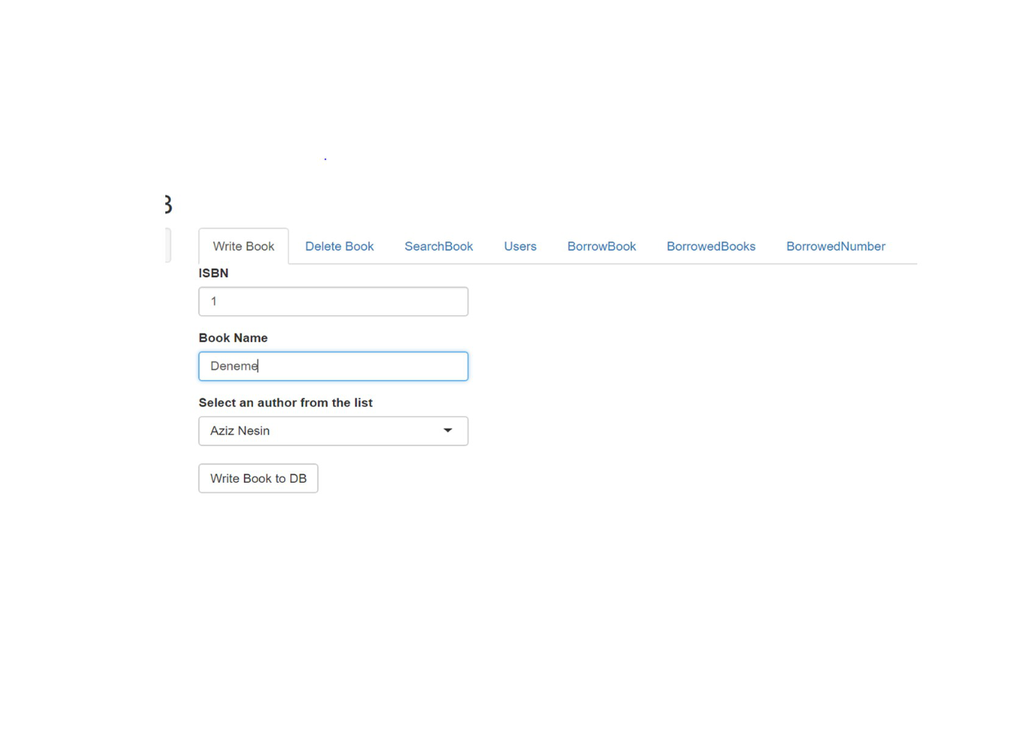

Search Book Interface:

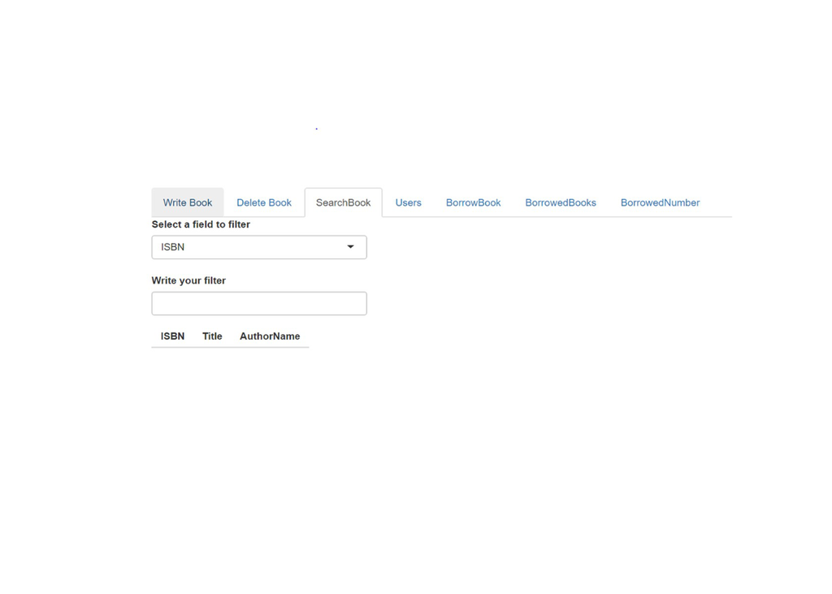

Borrow Book Interface:

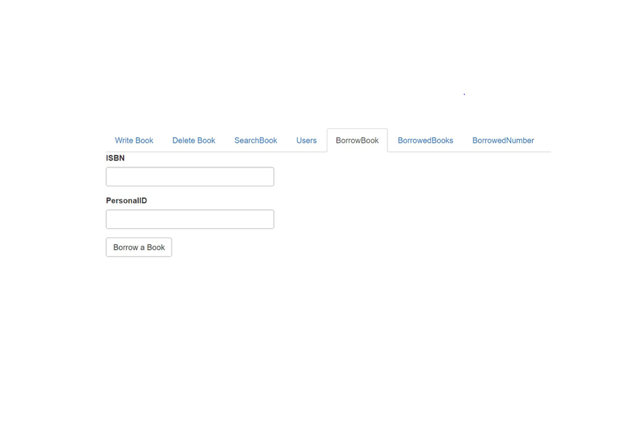